# Terrorism attacks

```python
import pandas as pd
import matplotlib.pyplot as plt
import numpy as np
import pandas as pd
pd.options.mode.chained_assignment = None
import plotly
import plotly.plotly as py
import plotly.graph_objs as go
from plotly import tools
from plotly.offline import iplot, init_notebook_mode
init_notebook_mode()

terror_data = pd.read_csv('globalterrorismdb_0617dist.csv', encoding='ISO-8859-1', dtype = None)
terror_data = terror_data.rename(
    columns={'eventid':'id', 'iyear':'year', 'imonth':'month', 'iday':'day'})
```

## How many attacks happened each year and what was average number of deaths per attack in the world?

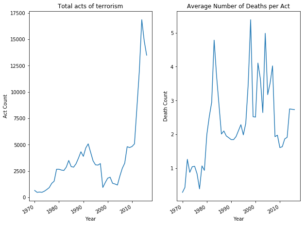

```python
count_year = terror_data.groupby(['year']).count()
mean_year = terror_data.groupby(['year']).mean()

fig = plt.figure(figsize = (10,8))
ax1 = fig.add_subplot(1,2,1)
ax2 = fig.add_subplot(1,2,2)
ax1.set(title = 'Total acts of terrorism', ylabel = 'Act Count', xlabel = 'Year')
ax1.plot(count_year.index, count_year.id)
ax2.set(title = 'Average Number of Deaths per Act', ylabel = 'Death Count', xlabel = 'Year')
ax2.plot(mean_year.index, mean_year.nkill)
fig.autofmt_xdate()
plt.show()
```

You can see an increasing act count, especially after 2010. On the other hand the average number of deaths per attack decreases after 2005.

## How many percent of attack consisted of multiple closely connected incidents?

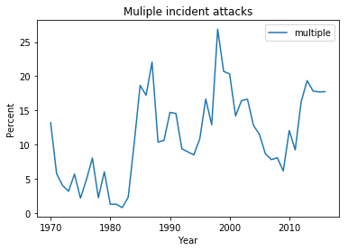

```python
column_names = ['year','multiple']
terror_multiple = terror_data[column_names]
pd.options.mode.chained_assignment = None
success_counts = terror_multiple[terror_multiple.multiple==1]['year'].value_counts().sort_index()
fail_counts = terror_multiple[terror_multiple.multiple==0]['year'].value_counts().sort_index()
all_incidents = success_counts + fail_counts
success_counts = success_counts/all_incidents * 100
plt.title('Muliple incident attacks')
plt.ylabel('Percent')
plt.xlabel('Year')
plt.plot(success_counts,label="multiple")
plt.legend(loc=1)
plt.show()
```

Recently attacks become more complex, e.g. incidents of the same attacks occur in multiple places at the same time.

## In Europe, where do the attacks happen the most frequently and how many people was dead or injured after 2000?

```python
terror_data['nkill'] = terror_data['nkill'].fillna(0).astype(int)
terror_data['nwound'] = terror_data['nwound'].fillna(0).astype(int)

# terrorist attacks in Europe
terror_europe = terror_data[((terror_data.region_txt == 'Western Europe') |
                         (terror_data.region_txt == 'Eastern Europe')) &
                           (terror_data.year > 2000)]
terror_europe['day'][terror_europe.day == 0] = 1
terror_europe['month'][terror_europe.month == 0] = 1
terror_europe['date'] = pd.to_datetime(terror_europe[['day', 'month', 'year']])
terror_europe = terror_europe[['id', 'date', 'year', 'provstate', 'latitude', 'longitude',
                         'targtype1_txt', 'weaptype1_txt', 'nkill', 'nwound']]
terror_europe = terror_europe.sort_values(['nkill', 'nwound'], ascending = False)
terror_europe = terror_europe.drop_duplicates(['date', 'latitude', 'longitude', 'nkill'])
terror_europe['text'] = terror_europe['date'].dt.strftime('%B %-d, %Y') + '<br>' +\
                     terror_europe['nkill'].astype(str) + ' Killed, ' +\
                     terror_europe['nwound'].astype(str) + ' Injured'

fatality = dict(
           type = 'scattergeo',
           lon = terror_europe[terror_europe.nkill > 0]['longitude'],
           lat = terror_europe[terror_europe.nkill > 0]['latitude'],
           text = terror_europe[terror_europe.nkill > 0]['text'],
           mode = 'markers',
           name = 'Fatality',
           hoverinfo = 'text+name',
           marker = dict(
               size = terror_europe[terror_europe.nkill > 0]['nkill'] ** 0.255 * 8,
               opacity = 0.95,
               color = 'rgb(240, 140, 45)')
           )

injury = dict(
         type = 'scattergeo',
         lon = terror_europe[terror_europe.nkill == 0]['longitude'],
         lat = terror_europe[terror_europe.nkill == 0]['latitude'],
         text = terror_europe[terror_europe.nkill== 0]['text'],
         mode = 'markers',
         name = 'Injury',
         hoverinfo = 'text+name',
         marker = dict(
             size = (terror_europe[terror_europe.nkill == 0]['nwound'] + 1) ** 0.245 * 8,
             opacity = 0.85,
             color = 'rgb(20, 150, 187)')
         )

layout = dict(
         title = 'Terrorist Attacks by Latitude/Longitude in Europe (2001-2016)',
         showlegend = True,
         legend = dict(
             x = 0.85, y = 0.4
         ),
         geo = dict(
             scope = 'europe',
             projection = dict(type = 'eckert4'),
             showland = True,
             landcolor = 'rgb(250, 250, 250)',
             subunitwidth = 1,
             subunitcolor = 'rgb(217, 217, 217)',
             countrywidth = 1,
             countrycolor = 'rgb(217, 217, 217)',
             showlakes = True,
             lakecolor = 'rgb(255, 255, 255)')
         )

data = [fatality, injury]
figure = dict(data = data, layout = layout)
iplot(figure)
```

[interactive chart not shown]

Wow! There was 3 terrorist attacks in Poland.

## What was the target of terrorist attacks in Western Europe and North America after 2010? What is the corelation this information with amount of dead and injured people.

```python
terror_data2011 = terror_data[((terror_data.region_txt == 'Western Europe') |
                         (terror_data.region_txt == 'North America')) &
                           (terror_data.year > 2010)]

terror_data2011['day'][terror_data2011.day == 0] = 1
terror_data2011['month'][terror_data2011.month == 0] = 1
terror_data2011['date'] = pd.to_datetime(terror_data2011[['day', 'month', 'year']])
terror_data2011 = terror_data2011[['id', 'date', 'year', 'latitude', 'longitude',
                         'targtype1_txt', 'nkill', 'nwound']]
terror_data2011 = terror_data2011.sort_values(['nkill', 'nwound'], ascending = False)
terror_data2011 = terror_data2011.drop_duplicates(['date', 'latitude', 'longitude', 'nkill'])


# terrorist attack targets grouped in categories
target_codes = []
for attack in terror_data2011['targtype1_txt'].values:
    if attack in ['Business', 'Journalists & Media', 'NGO']:
        target_codes.append(1)
    elif attack in ['Government (General)', 'Government (Diplomatic)']:
        target_codes.append(2)
    elif attack == 'Abortion Related':
        target_codes.append(4)
    elif attack == 'Educational Institution':
        target_codes.append(5)
    elif attack == 'Police':
        target_codes.append(6)
    elif attack == 'Military':
        target_codes.append(7)
    elif attack == 'Religious Figures/Institutions':
        target_codes.append(8)
    elif attack in ['Airports & Aircraft', 'Maritime', 'Transportation']:
        target_codes.append(9)
    elif attack in ['Food or Water Supply', 'Telecommunication', 'Utilities']:
        target_codes.append(10)
    else:
        target_codes.append(3)


terror_data2011['targtype1_txt'] = target_codes


target_categories = ['Business', 'Government', 'Individuals', 'Healthcare', 'Education',
                     'Police', 'Military', 'Religion', 'Transportation', 'Infrastructure']

# terrorist attacks by target
target_count = np.asarray(terror_data2011.groupby('targtype1_txt').targtype1_txt.count())
target_percent = np.round(target_count / sum(target_count) * 100, 2)

# terrorist attack fatalities by target
target_fatality = np.asarray(terror_data2011.groupby('targtype1_txt')['nkill'].sum())
target_yaxis = np.asarray([1.33, 2.36, 2.98, 0.81, 1.25, 1.71, 1.31, 1.53, 1.34, 0])

# terrorist attack injuries by target
target_injury = np.asarray(terror_data2011.groupby('targtype1_txt')['nwound'].sum())
target_xaxis = np.log10(target_injury)

target_text = []
for i in range(0, 9):
    target_text.append(target_categories[i] + ' (' + target_percent[i].astype(str)
                       + '%)<br>' + target_fatality[i].astype(str) + ' Killed, '
                       + target_injury[i].astype(str) + ' Injured')

data = [go.Scatter(
        x = target_injury,
        y = target_fatality,
        text = target_text,
        mode = 'markers',
        hoverinfo = 'text',
        marker = dict(
            size = target_count / 6.5,
            opacity = 0.9,
            color = 'rgb(240, 140, 45)')
        )]

layout = go.Layout(
         title = 'Terrorist Attacks by Target in Western Europe and Northen America (2011-2016)',
         xaxis = dict(
             title = 'Injuries',
             type = 'log',
             range = [1, 5],
             tickmode = 'auto',
             nticks = 2,
             showline = True,
             showgrid = False
         ),
         yaxis = dict(
             title = 'Fatality',
             type = 'log',
             range = [0, 4],
             tickmode = 'auto',
             nticks = 4,
             showline = True,
             showgrid = False)
         )

annotations = []
for i in range(0, 9):
    annotations.append(dict(x=target_xaxis[i], y=target_yaxis[i],
                            xanchor='middle', yanchor='top',
                            text=target_categories[i], showarrow=False))
layout['annotations'] = annotations

figure = dict(data = data, layout = layout)
iplot(figure)
```

[interactive chart not shown]

I don't expect that small amount of transportation attacts, but them was very dangerous.

## Which weapon did terrorist use in Europe? Which have the biggest amount of killed or injured victims?

```python
weapon_codes = []

for attack in terror_europe['weaptype1_txt'].values:
    if attack in ['Explosives/Bombs/Dynamite', 'Sabotage Equipment']:
        weapon_codes.append(1)
    elif attack == 'Incendiary':
        weapon_codes.append(2)
    elif attack in ['Firearms', 'Fake Weapons']:
        weapon_codes.append(3)
    elif attack == 'Melee':
        weapon_codes.append(5)
    elif attack == 'Biological':
        weapon_codes.append(6)
    elif attack in ['Chemical', 'Radiological']:
        weapon_codes.append(7)
    elif attack == 'Vehicle':
        weapon_codes.append(8)
    else:
        weapon_codes.append(4)

terror_europe['weaptype1_txt'] = weapon_codes
weapon_categories = ['Explosives', 'Flammables', 'Firearms', 'Miscellaneous',
                     'Knives', 'Bacteria/Viruses', 'Chemicals', 'Vehicles']

# terrorist attacks by weapon
weapon_count = np.asarray(terror_europe.groupby('weaptype1_txt').weaptype1_txt.count())
weapon_percent = np.round(weapon_count / sum(weapon_count) * 100, 2)

# terrorist attack fatalities by weapon
weapon_fatality = np.asarray(terror_europe.groupby('weaptype1_txt')['nkill'].sum())
weapon_yaxis = np.asarray([1.93, 1.02, 2.28, 0.875, 0.945, 0.83, 0.835, 3.2])

# terrorist attack injuries by weapon
weapon_injury = np.asarray(terror_europe.groupby('weaptype1_txt')['nwound'].sum())
weapon_xaxis = np.log10(weapon_injury)

weapon_text = []
for i in range(0, 6):
    weapon_text.append(weapon_categories[i] + ' (' + weapon_percent[i].astype(str)
                       + '%)<br>' + weapon_fatality[i].astype(str) + ' Killed, '
                       + weapon_injury[i].astype(str) + ' Injured')

weapon_fatality[5] = 7

data = [go.Scatter(
        x = weapon_injury,
        y = weapon_fatality,
        text = weapon_text,
        mode = 'markers',
        hoverinfo = 'text',
        marker = dict(
            size = (weapon_count + 50) / 10,
            opacity = 0.9,
            color = 'rgb(240, 140, 45)')
        )]

layout = go.Layout(
         title = 'Terrorist Attacks by Weapon in Europe (2011-2016)',
         xaxis = dict(
             title = 'Injuries',
             type = 'log',
             range = [0, 5],
             tickmode = 'auto',
             nticks = 4,
             showline = True,
             showgrid = False
         ),
         yaxis = dict(
             title = 'Fatality',
             type = 'log',
             range = [0, 8],
             tickmode = 'auto',
             nticks = 3,
             showline = True,
             showgrid = False)
         )

annotations = []
for i in range(0, 6):
    annotations.append(dict(x=weapon_xaxis[i], y=weapon_yaxis[i],
                            xanchor='middle', yanchor='top',
                            text=weapon_categories[i], showarrow=False))
layout['annotations'] = annotations

figure = dict(data = data, layout = layout)
iplot(figure)
```

[interactive chart not shown]

As you can see on the figure, terrorist most often used explosives and it was the most dangerous weapon in that years.